# Statistical analysis of the main study

Our study replicates Experiment 1A from the paper “What makes a word special? Words as unmotivated cues” (Edmiston & Lupyan, 2015). In this file, the statistical analysis of the main part of the study that followed the pilot study is documented. The complete analysis follows the guidelines of our study preregistration. In the experiment, participants hear an auditory sound cue that is either a word label describing a (basic-level) category (e.g. *dog*) or an environmental sound (e.g. the bark of a dog). After hearing the auditory cue, a picture of object or animal that belong to a certain category (e.g. a picture of a guitar) was presented. The participants had to indicate via button press, whether the sound cue and the picture belong to the same category.

# General information

```r
# load data
df <- read.csv("results_main.csv")
# Remove the last 12 submissions because they belong to the pilot study or are due to a bug fix
removed <- (df$submission_id<1700)
data <- df[!removed,]
data$submission_id %>% unique %>% length
```

```
## [1] 40
```

```r
head(data)
```

```
##   submission_id   RT age comments correctness cue_category cue_type
## 1          1974 3957  22              correct         bird    sound
## 2          1974 1970  22              correct         bird    label
## 3          1974 1222  22              correct         bird    label
## 4          1974 1664  22              correct         bird    label
## 5          1974 1851  22              correct         bird    sound
## 6          1974 1128  22              correct         bird    sound
##                       education      endTime expected experiment_id
## 1 Graduated High School/ Abitur 1.595963e+12    match           162
## 2 Graduated High School/ Abitur 1.595963e+12 no match           162
## 3 Graduated High School/ Abitur 1.595963e+12 no match           162
## 4 Graduated High School/ Abitur 1.595963e+12    match           162
## 5 Graduated High School/ Abitur 1.595963e+12    match           162
## 6 Graduated High School/ Abitur 1.595963e+12 no match           162
##             gender image_category            info key_pressed languages
```

[output cut: 34 more lines]

In total 40 participants took part in our main study. The main study design is equivalent to the pilot study design. The average age of our participants we retrieved via email and personal contact is 25.21. We included six different categories in our experimental design (*dog, guitar, drum, motor cycle, bird and phone*). For each of the six categories, there are four pictures. Two of those pictures show instances of one subcategory and two show instances of another subcategory. For example, the category *dog* is represented in four pictures, with two of them showing Miniature Poodles and two showing Labrador mixes.

## Data cleaning

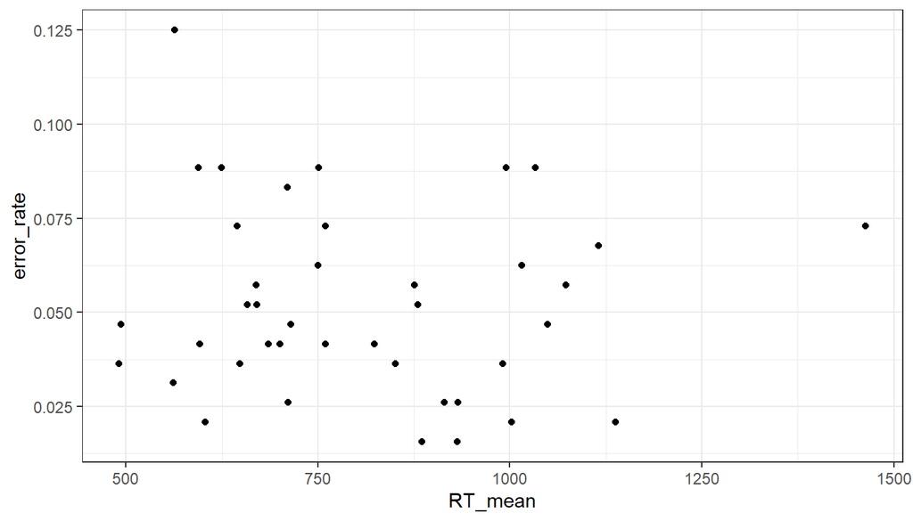

```r
# remove practice trials
df_main <- data[data$trial_type != 'practice',]

# rename column info to trial_info
names(df_main)[names(df_main)=="info"] <- "trial_info"

# Let's have a look at the participants mean reaction times and error rates
rt_means <- group_by(df_main, submission_id) %>% summarize(RT_mean=mean(RT), error_rate=mean(correctness=="incorrect"))
rt_means %>%
  ggplot(aes(x = RT_mean, y = error_rate)) +
  geom_point()
```

One can observe that the distribution of the reaction time means and error rates is relatively wide spread. Since this is an online-study participants are equipped with different hardware. It can happen that they experience difficulties with their internet connections or have problems with the safari browser or slowed netlify server. Therefore it happened that for some participants the pictures and the auditory sound cues could not be loaded in time. In those cases the participant has to guess if the category was matching or not, which may lead to higher error rates and/or longer reaction times. In the following we explain how we cleaned the data to keep reliable data despite those problems.

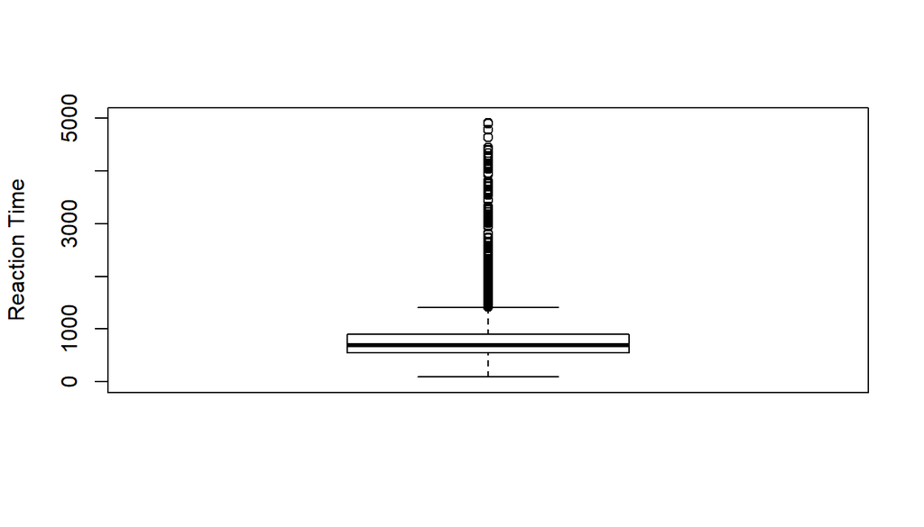

```r
# Calculate accuracy
cor_answers <- group_by(df_main, submission_id) %>% summarize(accuracy=sum(correctness=="correct")/length(correctness))

# We remove participants with an accuracy below 92% (based on comments of participants)
remove_incorrect <- cor_answers[cor_answers$accuracy<0.92,]$submission_id

# Add participant who commented that there were technical issues with the experiment to the remove list
remove_incorrect[8] <- 1737
df_testremove <- (df_main$submission_id%in%remove_incorrect)
df_main <- df_main[!df_testremove,]

# Set maximum and minimum values for reaction times to the value of the extreme of the upper whisker as maximum value and the extreme of the lower whisker as minimum value. We will remove data points that are above the maximum (max_RT) and those that are below the minimum (min_RT)
box_RT <- boxplot(df_main$RT, data=df_main, ylim = c(0, 5000), plot=TRUE, ylab = "Reaction Time")
```

```r
min_RT <- box_RT$stats[1]
max_RT <- box_RT$stats[5]

removed <- ((df_main$RT<min_RT) | (df_main$RT>max_RT))
percentage <- sum(removed)/length(df_main$RT)*100
data_clean <- df_main[!removed,]

accuracy <- sum(data_clean$correctness=="correct")/length(data_clean$correctness)

# We use only the trial data where the response was correct and if the categories were matching
data_cor_resp <- data_clean %>%
  filter(correctness == "correct" & expected =="match")
```

Based on the original experiment a normal accuracy would be 97%. Due to technical problems that occurred during the execution of the experiment, in some cases picture and auditory sound cues were not shown or they appeared with a delay that leads to higher error rates. We were able to detect a link of these problems to the Safari browser. Therefore, the instruction not to participate in the experiment using Safari was added. We decided to exclude participants that left a comment about technical issues in the post-test survey. This held for one participant. Because it is not possible to link the personally reported technical issues to specific data sets, we decided to remove all data from participants that showed an accuracy below the accuracy of the participant who experienced the described technical problems (92%). In total, data from 8 participants was excluded. Therefore, data from 32 participants remained for the statistical analysis.

Furthermore we will look at individual trials that have to be excluded because of suspicious long or short reaction times. The calculated value (following the procedure explained in the preregistration report) for minimum and maximum reaction times is y_min: 98ms and y_max: 1415ms. We removed 384 individual trials which is 6.25% of the trials from the data (including incorrect trials but excluding participants who had technical problems) because of too low or to high reaction times (outliers).

We only use data from those trials where the participants gave the correct response, that was the case in 96% of the trials. Since we are investigating the effect of incongruent and congruent environmental sound, as well as matching label-picture trials we exclude trials that did not represent a match between picture and sound category. Now our data set has 2762 trials.

When observing the histogram that shows the reaction time values of all participants, we notice that it is shaped logarithmically rather than normal distributed. The computation of the regression model assumes normal distributed data. In order to make more precise parameter estimation for the regression model used later, we apply a log-transformation to the reaction time values to get a more normalized distribution.

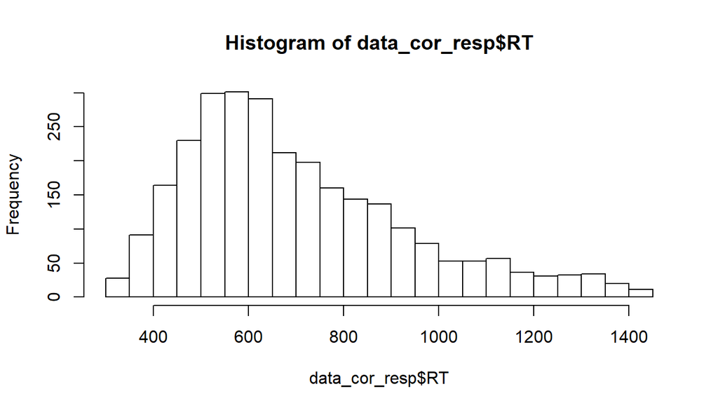

```r
hist(data_cor_resp$RT, breaks = 20)
```

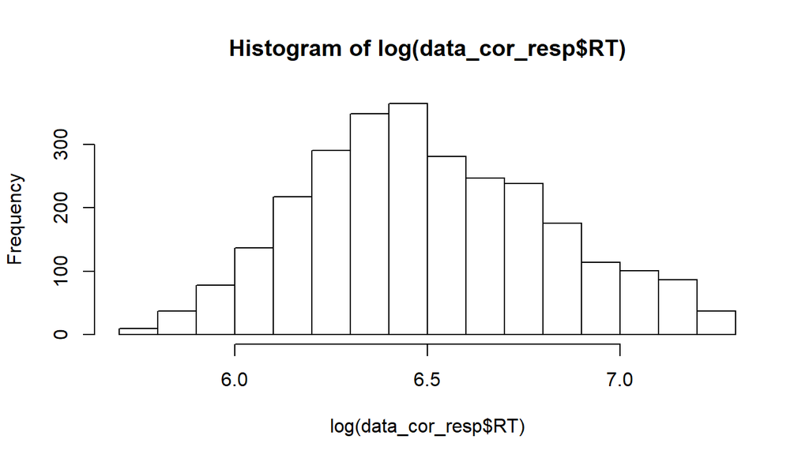

```r
hist(log(data_cor_resp$RT), breaks = 20)
```

```r
# Apply log-transformation onto the reaction times
data_cor_resp$RT_log <- log(data_cor_resp$RT)
```

```r
# We calculate the mean and the standard error for each trial type
overall_means <- group_by(data_cor_resp, trial_info) %>% summarise(RT = mean(RT))
overall_errors <- group_by(data_cor_resp, trial_info) %>% summarise(SE = sd(RT)/sqrt(length(RT)))
overall_means$SE <- overall_errors$SE
overall_means
```

```
## # A tibble: 3 x 3
##   trial_info       RT    SE
##   <fct>         <dbl> <dbl>
## 1 congruent      707.  9.00
## 2 incongruent    734.  9.92
## 3 label_correct  687.  5.85
```

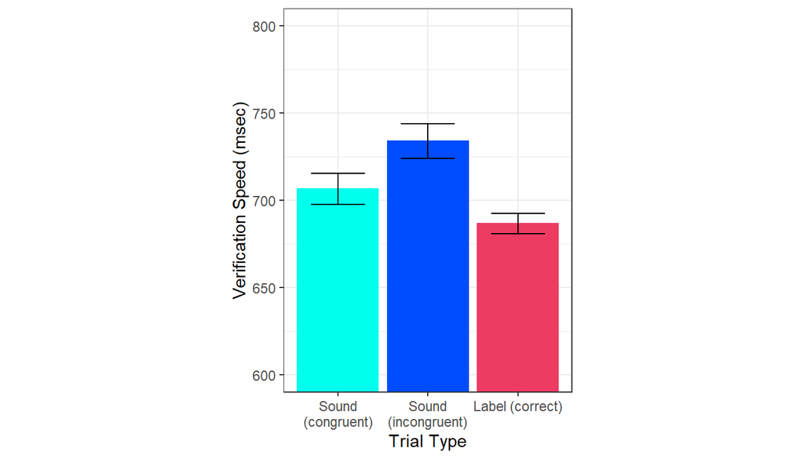

```r
# Plot the overall means depending on trial type
pl_colors <- c("#00FFED", "#004CFF", "#ED3B61")
rt_plot <- ggplot(overall_means, aes(x=trial_info, y=RT)) +
  geom_col(color=pl_colors, fill=pl_colors, position=position_dodge()) +
  geom_errorbar(aes(ymin=RT-SE, ymax=RT+SE), width=.6,
                 position=position_dodge(.9)) +
  theme(aspect.ratio = 4/3) +
  coord_cartesian(ylim=c(600,800)) +
  scale_x_discrete('Trial Type', labels=c('Sound\n(congruent)', 'Sound\n(incongruent)', 'Label (correct)')) +
    scale_y_continuous('Verification Speed (msec)')

rt_plot
```

The bar plot shows different means of reaction times for congruent environmental sound, incongruent environmental sound and verbal category label trials. This lets suggest that participants needed longer to verify the category match between auditory cue and picture of category instance, when the auditory cue was an environmental sound cue that is produced by the category instance on the picture. The longest reaction times are observed when the environmental sound cue is incongruent - it does fit in the category of the instance on the picture but is not the sound that is produced by the individual on the picture (e.g. the environmental cue is a acoustic guitar strum but the picture shows an electric guitar). We will further investigate the effect of verbal labels and environmental sound trials in the following analysis.

## Preparation for analysis

We use the simple (contrast) coding scheme to dummy code our factors cue_type and sound_type, which each have two levels. The procedure follows the explanation in the preregistration report and is the same as for the pilot study analysis. For more details please refer to one of the two documents (“final_pilot_analysis.html”, or “Preregistration Report.pdf” in the “writing” folder of the [GitHub repository](https://github.com/NelsAcquistapace/XPLab_SpecialWords_magpie).

```r
# We need a column that says if the sound was incongruent or congruent to the picture and has an NA in the label trials
data_cor_resp$sound_type <- ifelse(data_cor_resp$cue_type=='label', NA, ifelse(data_cor_resp$trial_info=="congruent", 'congruent', 'incongruent'))

data_cor_resp$cue_type <- as.factor(data_cor_resp$cue_type)
data_cor_resp$sound_type <- as.factor(data_cor_resp$sound_type)

# Prepare data set for analysis
# Applying the dummy coding from above on the two factors sound_type and cue_type
data_cor_resp$sound_type_nr <- ifelse(data_cor_resp$cue_type=='label', NA, ifelse(data_cor_resp$sound_type=="congruent", 0.5, -0.5))
data_cor_resp$cue_type_nr <- ifelse(data_cor_resp$cue_type=='label', -0.5, 0.5)

# We need a column where a unique trial ID is stated, that tells us about what picture/sound exactly it is. This will be included as a random effect in the linear mixed regression model
data_cor_resp$trialID <- paste(substring(data_cor_resp$picture, 18, nchar(as.character(data_cor_resp$picture))-4), substring(data_cor_resp$sound, 11, nchar(as.character(data_cor_resp$sound))-4), sep=":")
```

## Hypothesis testing

Now we are ready to start testing our hypotheses! Our two main hypotheses are based on the original paper:  
1. Environmental sound cues are not as effective as category labels in activating a concept. That is, reaction times for trials with environmental cues are higher than for trials with verbal labels.  
2. Sound cues activate specific category exemplars instead of general categories. That is, reaction times for congruent trials will be lower than for incongruent trials.

In the following analysis we will use linear mixed effects regression models that include our factors of interest as fixed effects (cue_type and sound_type) but also account for random effects, based on recommendations from the paper “Random effects structure for confirmatory hypothesis testing: Keep it maximal” (Barr et. al., 2013). This means that we want to keep the maximal complex model structure, without including unnecessary variables. The random effects account for random intercept and random slope effects of within-subject factors, as well as random intercept effects for unique trial types. A a more detailed explanation of the random effect structure follows below.

```r
# This function is used to compare the complex and the simpler model explained below. The methods used in the analysis we are using are based on and as close as possible to the methods used in the statistical analysis of the original paper.

model_comparison <- function(complex, simple, factor) {
  # First we compute the parameter estimation for the factor of interest
  coeff_complex_model <- summary(complex)$coefficients
  parameter <- coeff_complex_model[factor, 'Estimate']
  std_error <- coeff_complex_model[factor, 'Std. Error']

  # Compare the more complex model with the simple model. We compute the chi-square and the p-value that   we use for statistical inference.
  compare_with_simple <- anova(complex, simple)
  chi_sqr <- compare_with_simple['complex', 'Chisq']
  p_value <- compare_with_simple['complex', 'Pr(>Chisq)']
  report_comparison <- sprintf("Estimated parameter = %.2f ,(Std. Error: %.2f), Chi Sqr(1) = %.2f, p = %.4f", parameter, std_error, chi_sqr, p_value)

  list(report_comparison, compare_with_simple, parameter, std_error, p_value)
}
```

### Testing the first hypothesis

Now we investigate if the more complex model that includes the cue_type as a fixed effect fits better than the more simple model, that does not account for an fixed effect of the cue_type (verbal label vs. environmental cue) on the reaction time.

```r
# All the trials that were congruent and the picture was matching auditory label
cuetype <- lmer(RT_log ~ cue_type_nr + (1|submission_id) + (1|trialID), data=data_cor_resp[data_cor_resp$trial_info!='incongruent',])
cuetype.simple <- lmer(RT_log ~ 1 + (1|submission_id) + (1|trialID), data=data_cor_resp[data_cor_resp$trial_info!='incongruent',])
```

```r
# Using the function above to compare the complex and the simple model
results1 <- model_comparison(cuetype, cuetype.simple, "cue_type_nr")
results1[[2]]
## Data: data_cor_resp[data_cor_resp$trial_info != "incongruent", ]
## Models:
## simple: RT_log ~ 1 + (1 | submission_id) + (1 | trialID)
## complex: RT_log ~ cue_type_nr + (1 | submission_id) + (1 | trialID)
##         npar    AIC    BIC  logLik deviance  Chisq Df Pr(>Chisq)
## simple     4 330.05 352.71 -161.03   322.05
## complex    5 329.06 357.39 -159.53   319.06 2.9884  1    0.08386 .
## ---
## Signif. codes:  0 '***' 0.001 '**' 0.01 '*' 0.05 '.' 0.1 ' ' 1

# Now we would like to compute the confidence intervals to see how precise the parameter estimation is and how much it could vary if we would repeat the measurements.
confidence_int <- confint(cuetype, method='Wald', level=0.95)["cue_type_nr", ]
```

Summary of the results of testing for the effects mentioned in hypothesis nr. 1:  
- the parameter estimation for the factor cue_type is: B = 0.02, (Std. Error: 0.01) 95% CI [-0.00, 0.05]  
- the calculated p-value is: 0.08

Interpretation:  
The reported p-value is very close to be significant but is still higher than the significance level of 0.05. This strictly means that the model that assumes an effect of the factor cue type on the verification speed does not describe the observed data significantly better than the simpler model which does not include the factor of interest. All in all this means that the type of cue does not influence the verification speed of the participants and that verbal labels are as effective as (congruent) environmental sound cues. Still the p-value is very close to be significant which indicates a slight effect of the type of cue on the verification speed. The parameter for cue_type is slightly positive (CI [-0.003, 0.049]) which means that - if the complex model was right that there is an effect of cue_type - the reaction time is higher for environmental sound cues than for verbal category labels.

### Testing the second hypothesis

The second model states that the factor sound_type has an effect on the verification speed of the participants. We hypothesize that if the environmental cue is congruent to the instance of the category subgroup depicted (e.g. hearing a high-pitched dog bark followed by the picture of a small dog), leads to faster verification speed (lower RT) than the incongurent environmental sound cues (e.g. hearing a low-pitched dog bark followed by the picture of a small dog). Based on the original paper we assume that sound cues activate specific category exemplars instead of general categories. The complex model including the sound_type as factor of interest is compared to the simpler model that does not include the factor sound_type. The sound_type congruent is coded as 0.5 and the incongruent sound_type is coded as -0.5. According to the coding of the factor level congruent and incongruent we can state that congruent sound trials lead to lower reaction times, if the estimated parameter (computed from our more complex linear mixed effects regression model) for the factor sound_type is negative. Still this can only be concluded if the calculated p-value is below the significance threshold, which indicates that the model including the factor sound_type actually describes the underlying data appropriately.

For hypothesis 2 we fit the model:  
RT ~ sound_type + (1+sound_type | participantID) + (1 | trialID)

We compare it with the simpler model that does not include the factor sound_type  
RT ~ 1 + (1| participantID) + (1 | trialID)

Now we investigate if the more complex model that includes the sound_type as a fixed effect is more likely to fit the observed data better than the more simple model. The simpler model is an intercept-only model and does not include sound_type (congruent vs incongruent) as fixed effect on the reaction time.

```r
soundtype <- lmer(RT_log ~ sound_type_nr + (1+sound_type_nr|submission_id) + (1|trialID), data=data_cor_resp[data_cor_resp$cue_type == 'sound',])
soundtype.simple <- lmer(RT_log ~ 1 + (1|submission_id) + (1|trialID), data=data_cor_resp[data_cor_resp$cue_type == 'sound',])
```

```r
# Using the function above to compare the complex and the simple model
results2 <- model_comparison(soundtype, soundtype.simple, "sound_type_nr")
results2[[2]]
## Data: data_cor_resp[data_cor_resp$cue_type == "sound", ]
## Models:
## simple: RT_log ~ 1 + (1 | submission_id) + (1 | trialID)
## complex: RT_log ~ sound_type_nr + (1 + sound_type_nr | submission_id) +
## complex:     (1 | trialID)
##         npar    AIC    BIC  logLik deviance  Chisq Df Pr(>Chisq)
## simple     4 378.06 398.81 -185.03   370.06
## complex    7 378.62 414.95 -182.31   364.62 5.4359  3     0.1425

# Now we would like to compute the confidence intervals to see how precise the parameter estimation is and how much it could vary if we would repeat the measurements.
confidence_int2 <- confint(soundtype, method='Wald', level=0.95)["sound_type_nr", ]
```

Summary of the results of testing for the effects mentioned in hypothesis nr. 2:  
- the parameter estimation for the factor sound_type is: B = -0.04, (Std. Error: 0.02) 95% CI [-0.09, -0.00]  
- the calculated p-value is: 0.14

Interpretation: The calculated p-value is not below the significance threshold of 0.05. Therefore, we can conclude that the model that includes an effect of the sound type (congruent or incongruent) is not representing the underlying data better than the simpler model that does not include the factor. Contrary to our suppositions, the congruency of sound to the depicted instance of the category subgroup does not seem to have a significant effect on the verification speed of the participants. This contradicts the results of the study by Edminston and Lupyan (2015) who claim that sound activates specific category exemplars, which would lead to faster verification of the category in trials with congruent environmental sound cues. The estimated parameter for sound_type is negative ([-0.086, -0.002]), which means that the reaction time for congruent sound trials is lower than for incongruent sound trials. This result would match our hypothesis 2, but the evidence that there is a non-zero correlation between the independent variable sound_type and the dependent variable RT is insufficient.

Note on the power of our results:  
Since we had to exclude participants from our data, the sample size is small and therefore the power of the results is insufficient to claim that there is no effect of the cue type and the sound type on the reaction time. A larger number of participants could lead to a different p-value and reveal an effect of one or both factors on the dependent variable. Referring to the power analysis that we computed before the analysis was done, we would need more than 50 participants to achieve a power of 95%. For comparison: the original study had a number of 43 participants (power of 0.88), whereas we only had 32 valid participants, thus there is only 78% chance that the results of our hypotheses test is meaningful.

## Exploratory analysis

In the exploratory analysis we would like to investigate the more complex models above by performing a bayesian regression approach, using the brms package by Paul Buerkner (2016). It enables us to plot the posterior output of our model and lets us explore the model more visually and statistically. Furthermore, we will compare the estimated parameter for our two factors with the function compare_groups() using the `faintr` package.

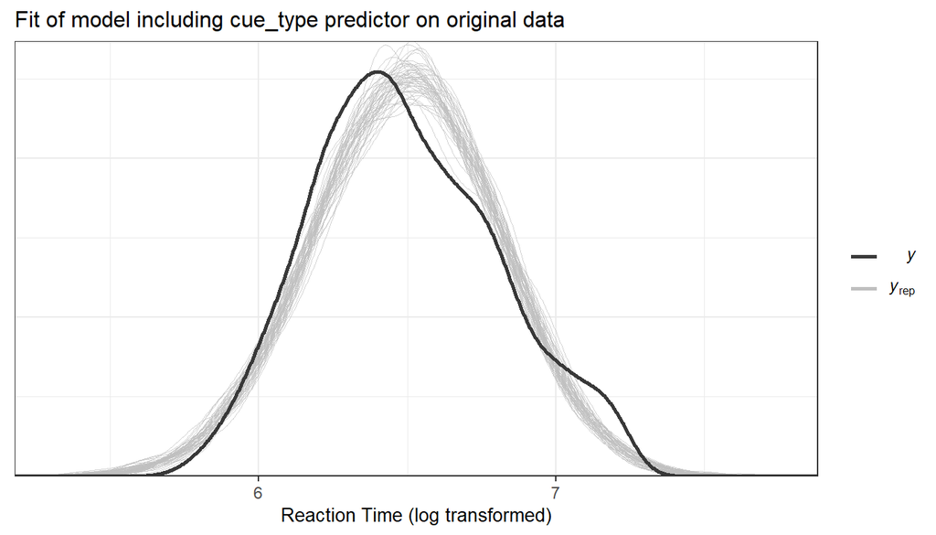

```r
# Function to plot the posteriors
plot_posterior <- function(model, data, plot_title) {
  pp_data <- posterior_predict(model, nsamples = 50)
color_scheme_set("gray" )
plot_dense <- ppc_dens_overlay(y = data, yrep = pp_data) +
  labs(x = "Reaction Time (log transformed)", title = plot_title) +
  theme(title = element_text(size=10))
  plot_dense
}

# Fit the two bayesian regression models
fit_cue_type <- brm(RT_log ~ cue_type + (1+cue_type|submission_id) + (1|trialID), data_cor_resp[data_cor_resp$trial_info != 'incongruent',], control = list(adapt_delta = 0.99), seed=1001)

fit_sound_type <- brm(RT_log ~ sound_type + (1+sound_type|submission_id) + (1|trialID), data_cor_resp[data_cor_resp$cue_type == 'sound',], control = list(adapt_delta = 0.99), seed=1002)

plot_posterior(fit_cue_type, data_cor_resp[data_cor_resp$trial_info != 'incongruent',]$RT_log, "Fit of model including cue_type predictor on original data")
```

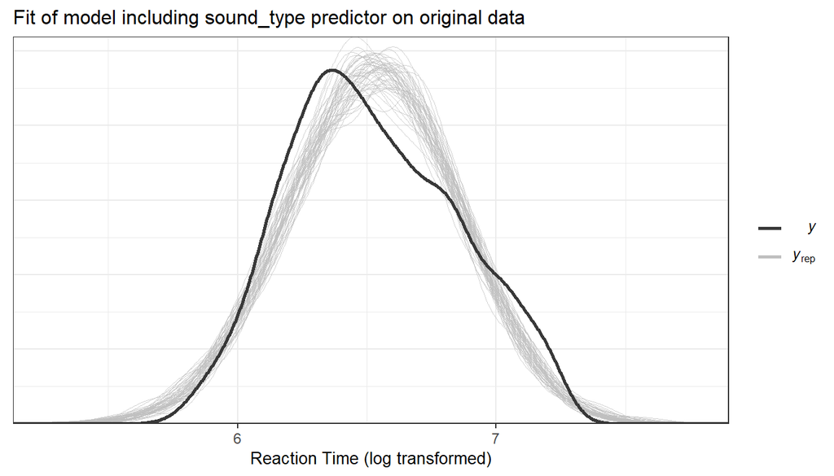

```r
plot_posterior(fit_sound_type, data_cor_resp[data_cor_resp$cue_type == 'sound',]$RT_log, "Fit of model including sound_type predictor on original data")
```

```r
# Now we compare the two conditions of both factors
# First we compare environmental condition with verbal label condition (the two levels of cue_type)
cue_type_compare <- compare_groups(
                      model = fit_cue_type,
                      higher = list("cue_type" = "sound"),
                      lower = list("cue_type" = "label")
                    )

# Second we compare the congruent with the incongruent sound type condition (the two levels of sound_type)
sound_type_compare <- compare_groups(
                        model = fit_sound_type,
                        higher = list("sound_type" = "incongruent"),
                        lower = list("sound_type" = "congruent")
                      )
```

The first two plots show the posterior distribution based on the two models - one model that includes cue_type as fixed effect and the other one includes sound_type as fixed effect - with the underlying data. In comparison to the two plots of the pilot study analysis we observe that the posterior distribution roughly fits the real data of the main study. The pilot study analysis could not provide enough data points to achieve a similar model fit. Still the plots above show small deviations, where the two complex models do not exactly fit the underlying data.

The results of the factor level comparison based on the two complex models show:  
1. It is likely (95%) that the verbal label cue leads to lower reaction times than the environmental sound cue.  
2. It is very likely (98%) that congruent sounds lead to a lower reaction time than incongruent sounds.

The first result matches the findings gained based on our linear mixed effects regression models. The second result shows that the negative effect of congruent environmental sound trials on reaction times is likely, but we don’t know if our model fits the data good enough to accept an existent effect of the sound type on reaction times. Comparing the two models visually, one can see that the model that includes sound_type has greater deviations from the data, than the model that includes cue_type. This lets us suggest that the effect of cue_type on the reaction time of the participants is more present in the underlying data than the effect of sound_type. The high probability in result 2 in comparison to 1 simply shows that the effect is larger for the factor sound_type than for the factor cue_type IF the effects are present.

### Exploratory hypothesis - Categories

When plotting the distribution of the reaction times in congruent sound cue trials dependent on categories we can see that there is a slight variation of performance. We assume that in some categories we find the sound more appropriate or more easy to recognize (environmental sound in conjunction with picture of a category) than in others. Here we will only examine the congruent sound trials. If it is true that some categories are more easy to recognize, then it is important to mention that the reduced efficiency of environmental sounds in comparison to verbal labels is to some extent dependent on the category. Some sounds could just be harder to identify, which does not necessarily mean that incongruent environmental sounds trials are significantly more difficult to verify as same category.

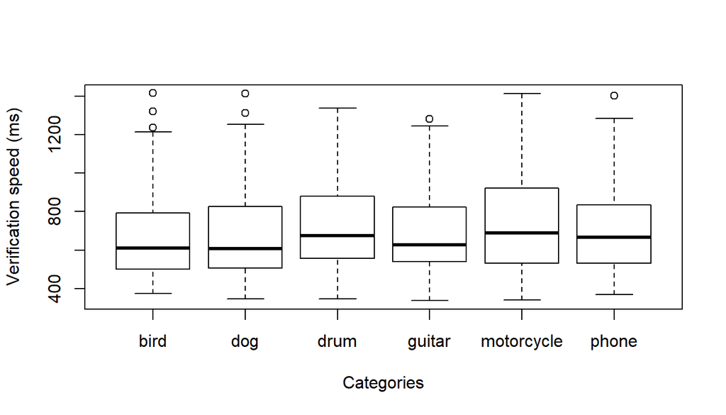

```r
congruent_trials <- data_cor_resp %>% filter(sound_type=="congruent")
categories_plot <- boxplot(RT ~ cue_category, data=congruent_trials, xlab = "Categories", ylab = "Verification speed (ms)")
```

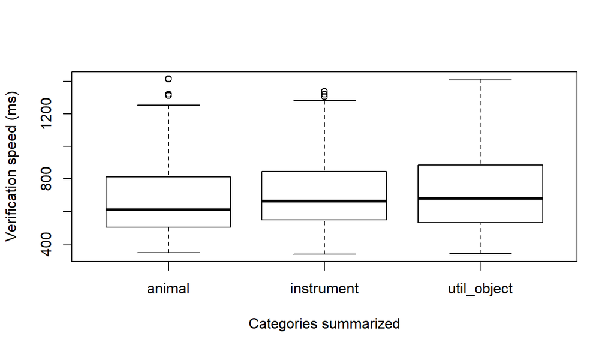

```r
congruent_trials$sum_categories <- ifelse(congruent_trials$cue_category=="dog"|congruent_trials$cue_category=="bird", "animal", ifelse(congruent_trials$cue_category=="guitar"|congruent_trials$cue_category=="drum", "instrument", "util_object"))

# Plot the data with the summarized categories (instruments -> guitar and drum, animals -> dog and bird and utility objects -> phone and motor cycle)
sum_categories_plot <- boxplot(RT ~ sum_categories, data=congruent_trials, xlab = "Categories summarized", ylab = "Verification speed (ms)")
```

We use the Bayesian approach to get a more information about the effect of categories on the verification speed in congruent environmental sound trials. We would like to know if there is a systematic effect of the selected categories on the reaction time that yields for all subjects. Since the plot suggests this effect we would explicitly like to know if animal sounds lead to faster reaction times than sounds belonging to instruments or utility objects.

Since subjects might be variously familiar with certain categories the model will include a random slope and random intercept effect. The random intercept (by-item) effect is included as well, because we still have unique trial type (like in the models above).

Hence our model looks like this:  
RT ~ category_sum + (1+ category_sum | participantID) + (1|trialID)

```r
category_mod <- brm(RT_log ~ sum_categories + (1+sum_categories|submission_id) + (1|trialID), congruent_trials, control = list(adapt_delta = 0.99), seed=2001)
params_cat <- fixef(category_mod)
params_cat
```

```
##                             Estimate  Est.Error         Q2.5     Q97.5
## Intercept                 6.48136331 0.04392326  6.392734277 6.5622351
## sum_categoriesinstrument  0.03840055 0.03192310 -0.024161228 0.1003712
## sum_categoriesutil_object 0.05794676 0.03422769 -0.009601974 0.1259987
```

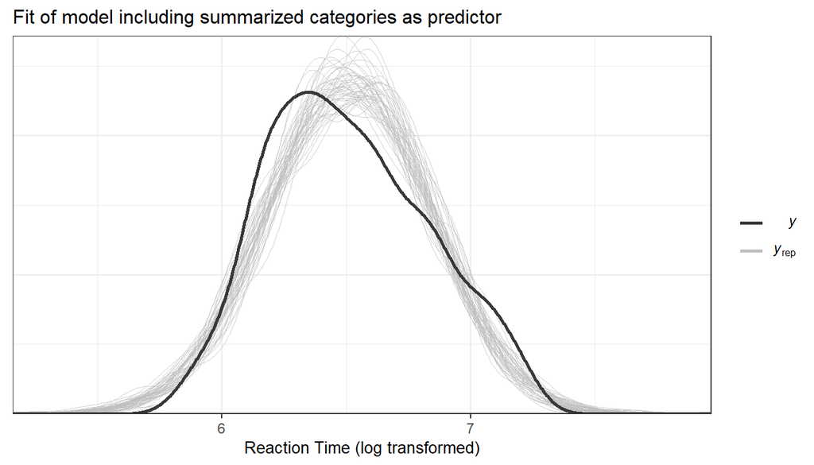

```r
# Plot the posterior distribution
plot_posterior(category_mod, congruent_trials$RT_log, "Fit of model including summarized categories as predictor")
```

```r
anim_instr <- compare_groups(category_mod,
               higher = list("sum_categories" = "instrument"),
               lower = list("sum_categories" = "animal"))

anim_util <- compare_groups(category_mod,
               higher = list("sum_categories" = "util_object"),
               lower = list("sum_categories" = "animal"))

util_instr <- compare_groups(category_mod,
               higher = list("sum_categories" = "instrument"),
               lower = list("sum_categories" = "util_object"))

instr_util <- compare_groups(category_mod,
               higher = list("sum_categories" = "util_object"),
               lower = list("sum_categories" = "instrument"))
```

To investigate how likely it is that trials with animal categories lead to a lower reaction time than trials with instrument or utility object categories and how likely it is that trials with instrument categories lead to lower/higher reaction time than trials with utility object categories, we use compare_groups().

- In 88% of the cases the sound of an animal is faster to recognize then the sound of an instrument.  
- In 95% of the cases the sound of an animal is faster to recognize then the sound of an utility object such as a phone or a motor cycle.  
- In 73% of the cases the sound of an instrument is faster to recognize then the sound of an utility object such as a phone or a motor cycle.

- The estimated parameter for the intercept of the model (animal categories) is 6.48 with a confidence interval [6.39, 6.56]. The intercept parameter is the expected average (log transformed) reaction time if the category is an animal. The parameter estimation for instrument categories is 0.04 with CI [-0.02, 0.1], for utility object categories 0.06 with CI [-0.01, 0.13] which means that the reaction time rises slightly, if the category is not an animal but an utility object or an instrument. The confidence interval for the latter two parameters shows that the estimated parameter values move around zero. Thus, the effect of the two categories on the verification speed is not constantly positive. It can be concluded that there is no significant correlation of the different categories on the reaction time on the participants. If we would add more categories to our experimental design this could of course change the results of this hypothesis test, since we do a between category caparison.

- In order to be critical with our model, we observe its posterior distribution and compare it to the underlying data. The plot shows that the model roughly fits but in some points deviates from the data. Because of the insufficient goodness of fit we cannot make statistically reliable conclusions about the effect of different categories on the verification speed.